# Intro to R

Dan Stich Biology Department, SUNY Oneonta

## Introduction

Welcome to programming in R. This script will serve as a tutorial to help you get aquainted with the R programming environment, and get you started with some basic tools and information that will help you along your way.

## Programming conventions

There are a lot of different ways to write computer code. Each has pros and cons and ALL of them are intended to increase efficiency and readability. For example, you’ll notice that none of my code goes beyond a certain vertical line in the editor. That is to make it so that people don’t have to scroll over to the right of the editor to see what I have written when I hand off my code. There is no “right” way to edit your code, but it will make your life easier if you find a style you like and stick to those conventions.

```r
# This is a comment
```

There are different ways to comment code in different languages. We use comments because the interpreters that send the code to a compiler won’t try to interpret commented code.

### Section breaks help organization

I like to use the built-in heading. It works really well for code-folding in R and when I’ve written a script that is several hundred lines long, some times all I want to see are the section headings. Go ahead and press the upside-down triangle to the right of the number 2 in the second line of code and see what it does.

### Stricter R programming rules:

All code is case sensitive

```r
# Example (run the following lines):
  a = 1
  A = 2
  a == A
```

```
## [1] FALSE
```

A few things going on here.

1. We’ve defined a couple of variables for the first time. A lot of purists insist that you use `<-` instead of `=` when you define variables (and they are correct), but for our purposes it will make absolutely no difference, and `=` is much faster to type than `<-`
2. Note that the two objects are not the same, and R knows this.
3. The `==` that we typed is a logical test that checks to see if the two objects are identical. If they were, then it would have returned a `TRUE` instead of `FALSE`. This ‘operator’ is very useful.

You can’t start an object name with a number, but you can end it with one

```r
    1a = 1 # In Rstudio there are nifty little markers to show this is broken
    a1 = 1 # This one works (try it by typing 'a1' in the console)
```

R will overwrite objects sequentially, so don’t name two things the same

```r
  a = 1
  a = 2
  a         # a takes on the second value here
```

```
## [1] 2
```

```r
  print(a)  # This is another way to look at the value of an object
```

```
## [1] 2
```

```r
  show(a)   # And, here is one more
```

```
## [1] 2
```

Some things can be expressed in multiple ways. Both ‘T’ and ‘TRUE’ can be used to indicate a logical that is T

```r
  T == TRUE
```

```
## [1] TRUE
```

Some names are reserved or pre-defined. Did you notice that R already knew what T and TRUE were? We will talk more this later in the course if we need to.

```r
  in, if, else, for, function()
```

…and a mess of others have special uses

Some *symbols* are also reserved for special use, like:

```r
*, % %, &, /, <, (, {, [, '', "", ...
```

…And a bunch of others. A lot of these are really useful

There are a few different ways to run a line of code:

1. Go the front of a line and press ctrl + r
   1. You can also press ctrl + Enter, but that won’t advance the cursor
2. Highlight a chunk of code and press one of the above combinations
3. Either 1 or 2, but press the ‘Run’ button at the top of this source file to run the code block.
4. Once you’ve run a code block you can change it and then press the button next to ‘Run’ above to ‘re-run’ the previous block of code

### Some handy coding tricks

The ‘home’ button will move you to the start of the line of code, and to the start of the line if you press it twice.

The ‘end’ button on your keyboard will take you to the end of a line so you can edit code. These will help you move around your code faster.

The ‘tab’ button on your keyboard will move the code to the right some number of spaces (user defined). Pressing SHIFT + Tab will move code to the left. These can help you organize your code.

Single click moves the cursor into position. Double click will highlight the word you are clicking, and a triple left click will highlight an entire line.

Use search and replace functionality to copy big chunks of code and change names as needed. Can also use this to just search your code. PRESS CTRL + F to open the sub menu at the top.

## Data structures

### Vectors

The first thing you need to know about R is that it’s a statistical programming language. It was designed by stats programmers to be used by stats practitioners. It is not a mathematical language, although it has a lot of math functionality. R is what is known as a “high-level” or “interpreted” programming language. This means the pieces that make it up are a little more intuitive to the average user than most low-level languages like C or C++. The back-end of R is, in fact, a collection of C, C++, Fortran, etc. code that builds up the functionality that we need. This means that R has a broad range of uses, from data management to math, and even GIS and data visualization tools, all of which are conveniently wrapped in an “intuitive”, “user-friendly” language. Translation: you can do a lot pretty easily.

The second thing you need to know about R is that it’s a “vectorized” language Why do you care about that? This will help you wrap your head around how objects are created and stored in R, which will help you understand how to make, access, modify, and combine the data that you will need for any approach to data analysis.

Let’s take a look at how this works and why it matters

```r
  a = 1
  # Here, we have defined 'a' as a variable with the value of 1...or have we?
  a
```

```
## [1] 1
```

What is the square bracket here? It’s an index. The index is telling us that the first element of ‘a’ is 1 This means that ‘a’ is actually a “Vector”, not a “Scalar”. You can think of a vector as a column in an excel spreadsheet or an analagous data table.

So, even if we define something with a singular value, it is still just a vector with one element (or row if that’s easier).

This is important because of the way that it let’s us do math. Even though it is a little difficult to wrap your head around now, it will help us out a lot in the future, and it makes vector operations so easy that we don’t even need to think about them when we start to make statistical models. In terms of programming, it can make a lot of things more intuitive than low- level languages, too.

The vector is the basic building block of life in R. Everything else is either made of vectors, or can be contained within one. Let’s play with some:

‘ATOMIC VECTORS’ can hold one kind of data:

Character Numeric Integer Logical Factor Date/time

Below are some examples of `atomic vectors`. Run the code to see what it does:

#### Integers and numerics

```r
    a = c(1, 2, 3, 4, 5) # Make a vector of integers 1 through five
    print(a) # One way to look at our vector
```

```
## [1] 1 2 3 4 5
```

```r
    show(a)  # Another way to look at it
```

```
## [1] 1 2 3 4 5
```

```r
    a        # A third way to look at it
```

```
## [1] 1 2 3 4 5
```

```r
    str(a)   # We can look at the structure of our vector, integer class
```

```
##  num [1:5] 1 2 3 4 5
```

```r
    # THINK: WHAT IS AN INTEGER? THIS WILL BE IMPORTANT DOWN THE ROAD WHEN WE
    # START TO LOOK AT DISCRETE VS CONTINUOUS PROBABILITY DISTRIBUTIONS
    a = seq(1:5) # Another way to make the same vector
    a            # Print the vector to the console
```

```
## [1] 1 2 3 4 5
```

```r
    str(a)       # Look at the data structure
```

```
##  int [1:5] 1 2 3 4 5
```

```r
    a = seq(from=8, to=13, by=1) # This is the long-hand; easier to understand
    str(a)       # Notice when we make the vector this way it is 'numeric'
```

```
##  num [1:6] 8 9 10 11 12 13
```

```r
    # AGAIN, THINK: WHAT IS THE DIFFERENCE BETWEEN NUMERIC AND INTEGER, WHAT IS
    # THE DIFFERENCE BETWEEN DISCRETE AND CONTINUOUS SCALES OF MEASUREMENT...
```

#### Characters and factors

```r
    b = c('a', 'b', 'c', 'd', 'e') # Make a character vector
    b                              # Print it to the console
```

```
## [1] "a" "b" "c" "d" "e"
```

```r
    str(b)                         # Now it's a character vector
```

```
##  chr [1:5] "a" "b" "c" "d" "e"
```

```r
    b = as.factor(b)               # But we can change that if we want
    b                              # WTF???
```

```
## [1] a b c d e
## Levels: a b c d e
```

```r
    str(b)                         # Look at the data structure for more info
```

```
##  Factor w/ 5 levels "a","b","c","d",..: 1 2 3 4 5
```

Factors are a special kind of data type in R that we may run across from time to time. They have ‘levels’ that can be ordered numerically. This is not really important except that it becomes really useful for coding variables used in matrices for statistical models- R does most of this behind the scenes and we won’t have to worry about it for the most part. In fact, in a lot of cases we will want to change factor vectors to character class so they are easier to manipulate.

```r
  as.numeric(b) # This is what it looks like when we code a factor as number
```

```
## [1] 1 2 3 4 5
```

```r
  ?as.numeric   # BTW: we can ask R what functions mean like this...
```

```
## starting httpd help server ... done
```

```r
                # And not just functions: we can ask it about pretty much
                # any built-in object. REMEMBER THIS.
```

#### Logical vectors

```r
    c = a == b   # Most of our logicals will be yes/no or comparisons
    c            # The '==' compares our numeric vector to the factor one
```

```
## [1] FALSE FALSE FALSE FALSE FALSE FALSE
```

```r
    str(c)       # We now have a logical vector
```

```
##  logi [1:6] FALSE FALSE FALSE FALSE FALSE FALSE
```

```r
    is.na(a)     # We can check for missing values
```

```
## [1] FALSE FALSE FALSE FALSE FALSE FALSE
```

```r
    is.finite(a) # We can make sure that all values are finite
```

```
## [1] TRUE TRUE TRUE TRUE TRUE TRUE
```

```r
    !is.na(a)    # The exclamation point means 'not' and is a logical operator
```

```
## [1] TRUE TRUE TRUE TRUE TRUE TRUE
```

```r
    a == 3       # We can see if specific elements of a vector meet a criterion
```

```
## [1] FALSE FALSE FALSE FALSE FALSE FALSE
```

```r
    unique(b)    # We can just look at uniue values
```

```
## [1] a b c d e
## Levels: a b c d e
```

Vectors only hold one data type

```r
    d = c(1, 'a', 2) #
```

If we try this it converts everything to the lowest common denominator. In this case, we can coerce numbers to characters, but there is no way to turn ‘a’ into an integer or numeric class meaningfully…

We can reference specific elements of vectors

```r
    a[3] # Here, we are printing the third element of 'a'
```

```
## [1] 10
```

```r
    b[b=='c'] # Here, we say, print any element of 'b' that is equal to 'c'
```

```
## [1] c
## Levels: a b c d e
```

```r
    which(b=='c') # Or, we can ask which elements equal 'c'
```

```
## [1] 3
```

We can do elementwise operations…

```r
    a * .5   # Multiplication
```

```
## [1] 4.0 4.5 5.0 5.5 6.0 6.5
```

```r
    a + 100  # Addition
```

```
## [1] 108 109 110 111 112 113
```

```r
    a - 3    # Subtraction
```

```
## [1]  5  6  7  8  9 10
```

```r
    a / 2    # Division
```

```
## [1] 4.0 4.5 5.0 5.5 6.0 6.5
```

```r
    a ^ 2    # Exponentiation
```

```
## [1]  64  81 100 121 144 169
```

```r
    exp(a)   # This is the same as 'e to the...'
```

```
## [1]   2980.958   8103.084  22026.466  59874.142 162754.791 442413.392
```

```r
    log(a)   # Natural logarithm
```

```
## [1] 2.079442 2.197225 2.302585 2.397895 2.484907 2.564949
```

```r
    log10(a) # Log base 10
```

```
## [1] 0.9030900 0.9542425 1.0000000 1.0413927 1.0791812 1.1139434
```

```r
    b = as.character(b)
    paste(b, 'AAAA', sep='') # We can append text
```

```
## [1] "aAAAA" "bAAAA" "cAAAA" "dAAAA" "eAAAA"
```

```r
    paste('AAAA', b, sep='') # We can do it the other way
```

```
## [1] "AAAAa" "AAAAb" "AAAAc" "AAAAd" "AAAAe"
```

```r
    paste('AAAA', b, sep='--') # Add symbols to separate
```

```
## [1] "AAAA--a" "AAAA--b" "AAAA--c" "AAAA--d" "AAAA--e"
```

```r
    gsub(pattern='c', replacement='AAAA', b) # We can replace text
```

```
## [1] "a"    "b"    "AAAA" "d"    "e"
```

```r
    e = paste('AAAA', b, sep='') # Make a new object
    e                            # Print to console
```

```
## [1] "AAAAa" "AAAAb" "AAAAc" "AAAAd" "AAAAe"
```

```r
    substr(e, start=5, stop=5)   # We can strip text (or dates, or times, etc.)
```

```
## [1] "a" "b" "c" "d" "e"
```

We can check how many elements they have…

```r
    length(a) # A has a length of 5, try it and check it
```

```
## [1] 6
```

```r
    a         # Yup, looks about right
```

```
## [1]  8  9 10 11 12 13
```

### Matrices

Matrices are made up of vectors

```r
# We can make matrices by binding vectors that already exist
  cbind(a,e)
```

```
##      a    e
## [1,] "8"  "AAAAa"
## [2,] "9"  "AAAAb"
## [3,] "10" "AAAAc"
## [4,] "11" "AAAAd"
## [5,] "12" "AAAAe"
## [6,] "13" "AAAAa"
```

```r
# Or we can make an empty one to fill
  matrix(0, nrow=3, ncol=4)
```

```
##      [,1] [,2] [,3] [,4]
## [1,]    0    0    0    0
## [2,]    0    0    0    0
## [3,]    0    0    0    0
```

```r
# Or we can make one from scratch
  mat = matrix(seq(1, 12), ncol=3, nrow=4)
# We can do all of the things we did with vectors to matrices, but now we
# have more than one column, and official 'rows'
  ncol(mat)   # Number of columns
```

```
## [1] 3
```

```r
  nrow(mat)   # Number of rows
```

```
## [1] 4
```

```r
  length(mat) # Total number of entries
```

```
## [1] 12
```

```r
  mat[2, 3]   # Value of row 2, column 3
```

```
## [1] 10
```

```r
  str(mat)    # See how no. of rows and columns is defined in data structure?
```

```
##  int [1:4, 1:3] 1 2 3 4 5 6 7 8 9 10 ...
```

```r
# With rows and columns, we can assign column names and row names. Honestly,
# we will almost never use these but you may come across it elsewhere
  colnames(mat) = c('first', 'second', 'third')
  rownames(mat) = c('This', 'is', 'a', 'matrix')
  mat
```

```
##        first second third
## This       1      5     9
## is         2      6    10
## a          3      7    11
## matrix     4      8    12
```

```r
  str(mat) # Take a look at the data structure and see if you understand
```

```
##  int [1:4, 1:3] 1 2 3 4 5 6 7 8 9 10 ...
##  - attr(*, "dimnames")=List of 2
##   ..$ : chr [1:4] "This" "is" "a" "matrix"
##   ..$ : chr [1:3] "first" "second" "third"
```

```r
  mat*2 # All the same operations we did on vectors above...one example
```

```
##        first second third
## This       2     10    18
## is         4     12    20
## a          6     14    22
## matrix     8     16    24
```

More on matrices as we need them. We won’t use these a lot in this course, but R relies heavily on matrices to do linear algebra behind the scenes in the models that we will be working with.

### Dataframes

Data frames are like matrices, only not. They have a row/column structure like matrices. But, they can hold more than one data type!

Data frames are made up of ‘ATOMIC VECTORS’

This, and the atomic vector, is probably the data structure that we will use most in this course.

Let’s make a dataframe:

```r
  a = seq(from=.5, to=10, by = .5)  # Make a sequence
  b = a^2                           # Vector math- raise each 'a' to power of 2
  c = rep(c('a','b','c','d'), 5)    # Replicates values in object a # of times
  d = data.frame(a, b, c)           # Note, we don't use quotes for objects
```

Now we can look at it:

```r
  d # Print the dataframe
```

```
##       a      b c
## 1   0.5   0.25 a
## 2   1.0   1.00 b
## 3   1.5   2.25 c
## 4   2.0   4.00 d
## 5   2.5   6.25 a
## 6   3.0   9.00 b
## 7   3.5  12.25 c
## 8   4.0  16.00 d
## 9   4.5  20.25 a
## 10  5.0  25.00 b
## 11  5.5  30.25 c
## 12  6.0  36.00 d
## 13  6.5  42.25 a
## 14  7.0  49.00 b
## 15  7.5  56.25 c
## 16  8.0  64.00 d
## 17  8.5  72.25 a
## 18  9.0  81.00 b
## 19  9.5  90.25 c
## 20 10.0 100.00 d
```

Notice that R assigns names to dataframes on the fly based on object names. They are not `colnames` as with matrices, they are `names`.

```r
  # We can look at these
    names(d)     # All of the names
```

```
## [1] "a" "b" "c"
```

```r
    names(d)[2]  # One at a time: note indexing, names(d) is a vector!!
```

```
## [1] "b"
```

```r
  # We can change the names
    names(d) = c('Increment', 'Squared', 'Class') # All at once- note quotes
    names(d)               # Print it to see what this does
```

```
## [1] "Increment" "Squared"   "Class"
```

```r
    names(d)[3] = 'Letter' # Or, one at a time..
    names(d)               # Print it again to see what changed
```

```
## [1] "Increment" "Squared"   "Letter"
```

```r
    e = d                  # We can also rename the entire dataframe
    head(e)                # This will show us the first six rows of a dataframe
```

```
##   Increment Squared Letter
## 1       0.5    0.25      a
## 2       1.0    1.00      b
## 3       1.5    2.25      c
## 4       2.0    4.00      d
## 5       2.5    6.25      a
## 6       3.0    9.00      b
```

```r
    head(e, 10)            # Or, we can look at any other number that we want
```

```
##    Increment Squared Letter
## 1        0.5    0.25      a
## 2        1.0    1.00      b
## 3        1.5    2.25      c
## 4        2.0    4.00      d
## 5        2.5    6.25      a
## 6        3.0    9.00      b
## 7        3.5   12.25      c
## 8        4.0   16.00      d
## 9        4.5   20.25      a
## 10       5.0   25.00      b
```

```r
    e$Sqrt = sqrt(e$Increment)
    e # We can make new columns in data frames really easily like this!
```

```
##    Increment Squared Letter      Sqrt
## 1        0.5    0.25      a 0.7071068
## 2        1.0    1.00      b 1.0000000
## 3        1.5    2.25      c 1.2247449
## 4        2.0    4.00      d 1.4142136
## 5        2.5    6.25      a 1.5811388
## 6        3.0    9.00      b 1.7320508
## 7        3.5   12.25      c 1.8708287
## 8        4.0   16.00      d 2.0000000
## 9        4.5   20.25      a 2.1213203
## 10       5.0   25.00      b 2.2360680
## 11       5.5   30.25      c 2.3452079
## 12       6.0   36.00      d 2.4494897
## 13       6.5   42.25      a 2.5495098
## 14       7.0   49.00      b 2.6457513
## 15       7.5   56.25      c 2.7386128
## 16       8.0   64.00      d 2.8284271
## 17       8.5   72.25      a 2.9154759
## 18       9.0   81.00      b 3.0000000
## 19       9.5   90.25      c 3.0822070
## 20      10.0  100.00      d 3.1622777
```

Looking at specific elements of a dataframe is similar to a matrix, with some added capabilities. We’ll do this with some real data so it’s more fun. Most of the packages in R have built in data sets that we can use for examples. Let’s start by looking at the Iris data.

```r
    data('iris')  # This is how you load built-in data sets
    ls()          # We can use ls() to see what is in our environment
```

```
## [1] "a"    "A"    "b"    "c"    "d"    "e"    "iris" "mat"
```

```r
    head(iris)    # Look at the first six rows of data in the object
```

```
##   Sepal.Length Sepal.Width Petal.Length Petal.Width Species
## 1          5.1         3.5          1.4         0.2  setosa
## 2          4.9         3.0          1.4         0.2  setosa
## 3          4.7         3.2          1.3         0.2  setosa
## 4          4.6         3.1          1.5         0.2  setosa
## 5          5.0         3.6          1.4         0.2  setosa
## 6          5.4         3.9          1.7         0.4  setosa
```

```r
    nrow(iris)    # How many rows does it have?
```

```
## [1] 150
```

```r
    ncol(iris)    # How many columns?
```

```
## [1] 5
```

```r
    names(iris)   # What are the column names?
```

```
## [1] "Sepal.Length" "Sepal.Width"  "Petal.Length" "Petal.Width"
## [5] "Species"
```

```r
    str(iris)     # Have a look at the data structure- tells us all of the above
```

```
## 'data.frame':    150 obs. of  5 variables:
##  $ Sepal.Length: num  5.1 4.9 4.7 4.6 5 5.4 4.6 5 4.4 4.9 ...
##  $ Sepal.Width : num  3.5 3 3.2 3.1 3.6 3.9 3.4 3.4 2.9 3.1 ...
##  $ Petal.Length: num  1.4 1.4 1.3 1.5 1.4 1.7 1.4 1.5 1.4 1.5 ...
##  $ Petal.Width : num  0.2 0.2 0.2 0.2 0.2 0.4 0.3 0.2 0.2 0.1 ...
##  $ Species     : Factor w/ 3 levels "setosa","versicolor",..: 1 1 1 1 1 1 1 1 1 1 ...
```

```r
    summary(iris) # Summarize the variables in the dataframe
```

```
##   Sepal.Length    Sepal.Width     Petal.Length    Petal.Width
##  Min.   :4.300   Min.   :2.000   Min.   :1.000   Min.   :0.100
##  1st Qu.:5.100   1st Qu.:2.800   1st Qu.:1.600   1st Qu.:0.300
##  Median :5.800   Median :3.000   Median :4.350   Median :1.300
##  Mean   :5.843   Mean   :3.057   Mean   :3.758   Mean   :1.199
##  3rd Qu.:6.400   3rd Qu.:3.300   3rd Qu.:5.100   3rd Qu.:1.800
##  Max.   :7.900   Max.   :4.400   Max.   :6.900   Max.   :2.500
##        Species
##  setosa    :50
##  versicolor:50
##  virginica :50
##
##
##
```

```r
  # Now let's look at some specific things
    # What is the value in 12th row of the 4th column of iris?
      iris[12, 4]
```

```
## [1] 0.2
```

```r
    # What is the mean sepal length among all species in iris?
      mean(iris$Sepal.Length)
```

```
## [1] 5.843333
```

```r
    # What about the mean sepal length just for setosa?
      # A couple of new things going on here:
      # 1. We can refer to the columns as atomic vectors within the dataframe if
      #    we want to. Some times we have to do this...
      # 2. Note the logical check for species
      # 3. What we are saying here is:
      #    "Show me the mean of the column Sepal.Length in the dataframe iris
      #    where the species name is setosa"
        mean(iris$Sepal.Length[iris$Species=='setosa'])
```

```
## [1] 5.006
```

```r
      # We can write this out longhand to make sure it's correct (it is)
        logicalCheck = iris$Species == 'setosa'
        lengthCheck = iris$Sepal.Length[iris$Species=='setosa']
      # We can also look at the whole dataframe just for setosa
        setosaData = iris[iris$Species=='setosa' , ]
        # Note that the structure of species is preserved as a factor with three
        # levels even though setosa is the only species name in the new df
          str(setosaData)
```

```
## 'data.frame':    50 obs. of  5 variables:
##  $ Sepal.Length: num  5.1 4.9 4.7 4.6 5 5.4 4.6 5 4.4 4.9 ...
##  $ Sepal.Width : num  3.5 3 3.2 3.1 3.6 3.9 3.4 3.4 2.9 3.1 ...
##  $ Petal.Length: num  1.4 1.4 1.3 1.5 1.4 1.7 1.4 1.5 1.4 1.5 ...
##  $ Petal.Width : num  0.2 0.2 0.2 0.2 0.2 0.4 0.3 0.2 0.2 0.1 ...
##  $ Species     : Factor w/ 3 levels "setosa","versicolor",..: 1 1 1 1 1 1 1 1 1 1 ...
```

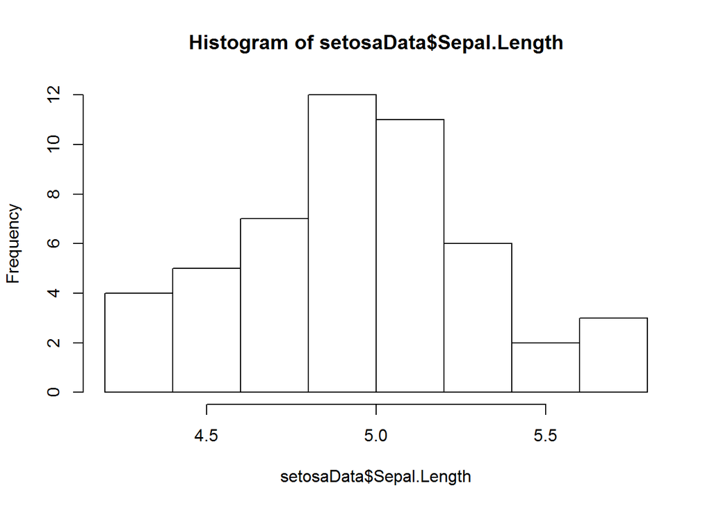

```r
      # Some quick plotting code
      # Once we have a nice dataframe like these ones, we can actually step into
      # The world of exploratory analyses.
        hist(setosaData$Sepal.Length) # Make a histogram of sepal lengths
```

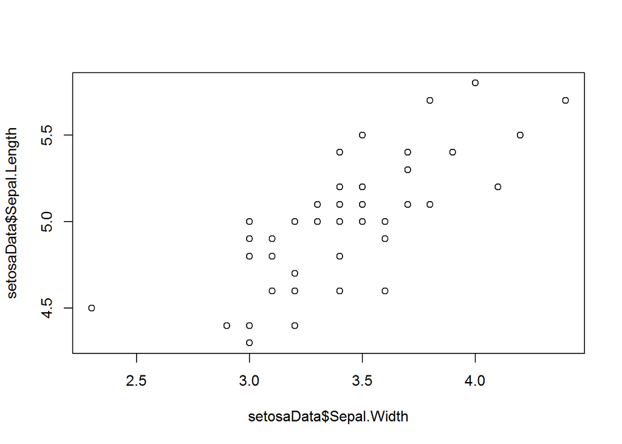

```r
        plot(setosaData$Sepal.Width, setosaData$Sepal.Length) # Bi-plot
```

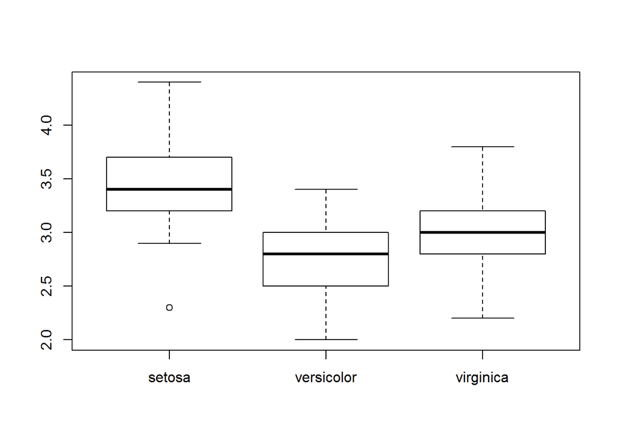

```r
        boxplot(Sepal.Width~Species, data=iris) # Boxplots
```

### Lists

Lists are the ultimate data type in R. They are actually a vector that can hold different classes of data. Each element of a list can be any kind of object (an atomic vector, a matrix, a dataframe, or even another list!!).

The real, filthy R programming relies heavily on lists. We will have to work with them at some point in this class, but we won’t take a ton of time on them here.

Let’s make a list- just to see how they work

```r
  myList = vector(mode='list', length=4)
  myList[[1]] = a
  myList[[2]] = c
  myList[[3]] = mat
  myList[[4]] = d

# Print it
  myList                                   # Cool, huh?
```

```
## [[1]]
##  [1]  0.5  1.0  1.5  2.0  2.5  3.0  3.5  4.0  4.5  5.0  5.5  6.0  6.5  7.0
## [15]  7.5  8.0  8.5  9.0  9.5 10.0
##
## [[2]]
##  [1] "a" "b" "c" "d" "a" "b" "c" "d" "a" "b" "c" "d" "a" "b" "c" "d" "a"
## [18] "b" "c" "d"
##
## [[3]]
##        first second third
## This       1      5     9
## is         2      6    10
## a          3      7    11
## matrix     4      8    12
##
## [[4]]
##    Increment Squared Letter
## 1        0.5    0.25      a
## 2        1.0    1.00      b
## 3        1.5    2.25      c
## 4        2.0    4.00      d
## 5        2.5    6.25      a
## 6        3.0    9.00      b
## 7        3.5   12.25      c
## 8        4.0   16.00      d
## 9        4.5   20.25      a
## 10       5.0   25.00      b
## 11       5.5   30.25      c
## 12       6.0   36.00      d
## 13       6.5   42.25      a
## 14       7.0   49.00      b
## 15       7.5   56.25      c
## 16       8.0   64.00      d
## 17       8.5   72.25      a
## 18       9.0   81.00      b
## 19       9.5   90.25      c
## 20      10.0  100.00      d
```

```r
  names(myList)                            # No names on the fly like a df
```

[output not shown]

```r
  names(myList) = c('a', 'c', 'mat', 'd')  # Give it names like a dataframe
  myList                                   # See how the names work now?
```

```
## $a
##  [1]  0.5  1.0  1.5  2.0  2.5  3.0  3.5  4.0  4.5  5.0  5.5  6.0  6.5  7.0
## [15]  7.5  8.0  8.5  9.0  9.5 10.0
##
## $c
##  [1] "a" "b" "c" "d" "a" "b" "c" "d" "a" "b" "c" "d" "a" "b" "c" "d" "a"
## [18] "b" "c" "d"
##
## $mat
##        first second third
## This       1      5     9
## is         2      6    10
## a          3      7    11
## matrix     4      8    12
##
## $d
##    Increment Squared Letter
## 1        0.5    0.25      a
## 2        1.0    1.00      b
## 3        1.5    2.25      c
## 4        2.0    4.00      d
## 5        2.5    6.25      a
## 6        3.0    9.00      b
## 7        3.5   12.25      c
## 8        4.0   16.00      d
## 9        4.5   20.25      a
## 10       5.0   25.00      b
## 11       5.5   30.25      c
## 12       6.0   36.00      d
## 13       6.5   42.25      a
## 14       7.0   49.00      b
## 15       7.5   56.25      c
## 16       8.0   64.00      d
## 17       8.5   72.25      a
## 18       9.0   81.00      b
## 19       9.5   90.25      c
## 20      10.0  100.00      d
```

```r
  myList[[1]]                              # We reference these differently [[]]
```

```
##  [1]  0.5  1.0  1.5  2.0  2.5  3.0  3.5  4.0  4.5  5.0  5.5  6.0  6.5  7.0
## [15]  7.5  8.0  8.5  9.0  9.5 10.0
```

```r
  myList[[2]][5]                           # But can still get into each object
```

```
## [1] "a"
```

```r
  # Play around with the numbers to see what they do!
  myList$c[1]                              # Can also reference it this way!
```

```
## [1] "a"
```

Very commonly, model objects and output are stored as lists. In fact, most objects that require a large amount of diverse information in R pack it all together in one place using lists, that way we always know where to find it. It seems like a lot to take in now, but will be very useful in the future.